# Lab 06 - Political Polarization 1

Bao Linh Hoang

10/17/2023

## Introduction - Political Polarization

Polarization is all over the news. One need only look at facebook news feeds, news media, and political coverage to see coverage of how divided Washington, D.C. is politically. Usually, polarization is described as hyper-partisanship with members of one party deeply divided from that of the other(s). Yet, the extent of this polarization, its consequences, and causes remains a question of interest to scholars, pundits, politicians, and policy makers. Indeed, if polarization, whether partisan or not, is not new then perhaps lessons from the past can inform the present. Furthermore, depending on the possible causes and consequences of polarization, the way in which we view polarization may not be entirely “good” or “bad,” but rather a means to better understand politics and how it plays a role in the legislative process. Data analytics can help us unpack polarization, understand its causes and consequences, challenge conventional wisdom about opportunities for cooperation, and strategize about future trends.

## Method

### Exploring and setting up the House data

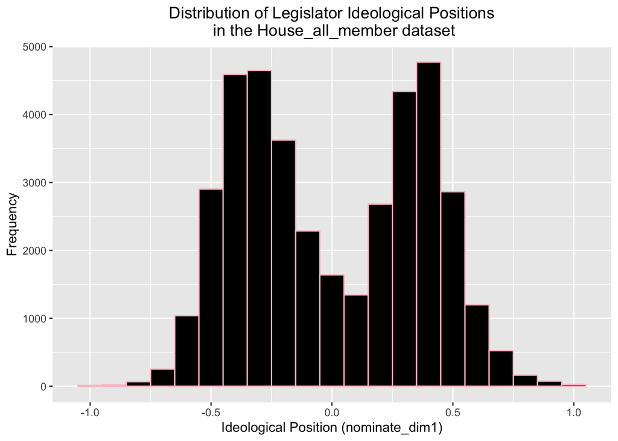

```r
presidents<- filter(House_all_members, chamber=="Presidents")
house_members<-filter(House_all_members,chamber=="House")
ggplot(data = House_all_members, aes(x = nominate_dim1)) + geom_histogram(binwidth = 0.1, fill = "black", color = "pink") + labs( x = "Ideological Position (nominate_dim1)", y = "Frequency", title = "Distribution of Legislator Ideological Positions\n in the House_all_member dataset") + theme(plot.title = element_text(hjust = 0.5))
```

```r
t.test(house_members$nominate_dim1)
```

```
##
##  One Sample t-test
##
## data:  house_members$nominate_dim1
## t = 1.933, df = 38964, p-value = 0.05324
## alternative hypothesis: true mean is not equal to 0
## 95 percent confidence interval:
##  -5.103733e-05  7.355233e-03
## sample estimates:
##   mean of x
## 0.003652098
```

### Analysis over time and across subsets of the data

1. During the late 1700s, we can see a conservative trend, but over time the trend gradually leaned towards a more liberal side. From 1860 to 1940, we can see a big gap in the 0 mark, which indicates a strong polarization with more people leaning towards two opposite ideologies; nevertheless, the trend spread between the -0.75 to 0.75 mark before the year 2000 which we can see a polarization again to the present day. There are many polarization periods, with a limited presence of independent perspectives.

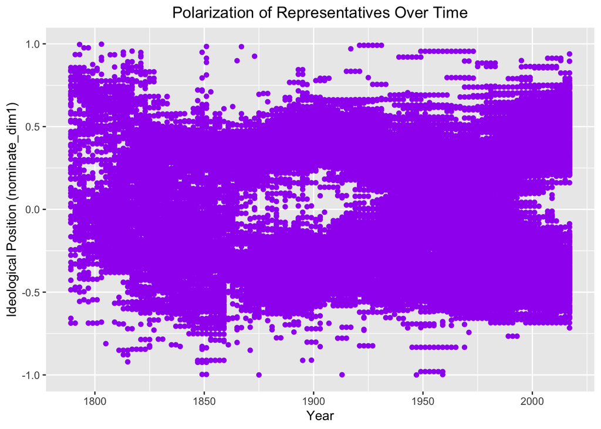

```r
House_all_members<-mutate(House_all_members, Congress_Year = 1789 + (congress - 1) * 2)
ggplot(data = House_all_members, aes(x = Congress_Year, y = nominate_dim1)) + geom_point(color = "purple") +labs(x = "Year", y = "Ideological Position (nominate_dim1)", title = "Polarization of Representatives Over Time") + theme(plot.title = element_text(hjust = 0.5))
```

2. In this line of code, geom_jitter is used to create a scatter plot with added jitter, which introduces a slight random variation to data points to prevent overlapping, with each point represents a legislator’s ideological position (nominate_dim1) over time (Congress_Year), and the color of the points is determined by their political party (party_code). We can see that before 1860, there are many parties; however, after that we can see that the two dominate parties start to show up, with the green coloured being very conservative and the brown yellow being very liberal. There were periods of time that mark the two parties’ polarization such as from 1860 to 1940 and from 2000 to present day.

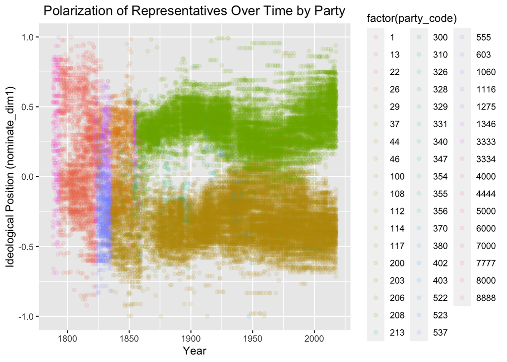

```r
ggplot(data = House_all_members, aes(x = Congress_Year, y = nominate_dim1, color = factor(party_code))) + geom_jitter(alpha = 1/10) + labs( x = "Year", y = "Ideological Position (nominate_dim1)", title = "Polarization of Representatives Over Time by Party") + theme(plot.title = element_text(hjust = 0.5))
```

3. The nested ifelse logic in the code creates a new variable named twoparty in the house1876 data set. It assigns a value of 0 to legislators who are Democrats (party_code 100), a value of 1 to Republicans (party_code 200), and NA to all other parties. This logic efficiently categorizes legislators into the two major parties, allowing for easy analysis of polarization trends within the data set.

```r
house1876 <- filter(House_all_members, Congress_Year >= 1876)
house1876 <- mutate(house1876,twoparty=ifelse(party_code!=100 & party_code!=200, NA_integer_, ifelse(party_code==200, 1, 0)))
```

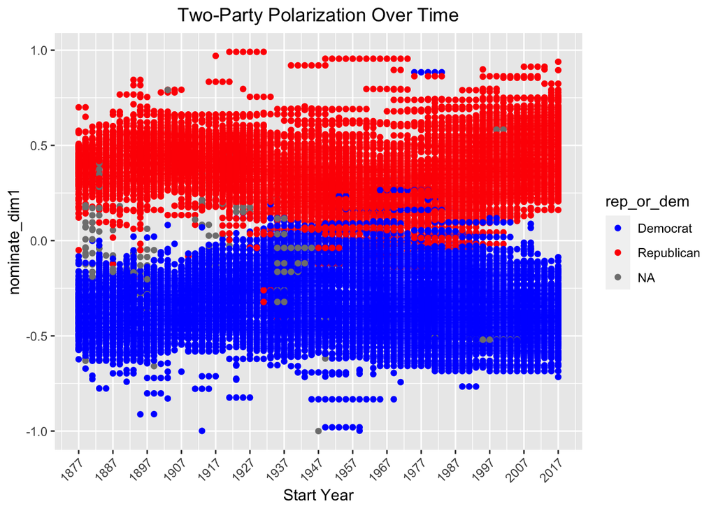

```r
house1876 <- mutate(house1876, rep_or_dem = ifelse(twoparty == 0, "Democrat", "Republican"))
ggplot(data = house1876, aes(x = Congress_Year, y = nominate_dim1, color = rep_or_dem)) + geom_point() + scale_color_manual(values = c("blue", "red")) + labs( x = "Start Year", y = "nominate_dim1", title = "Two-Party Polarization Over Time") + scale_x_continuous(breaks = seq(1877, 2017, 10)) + theme(axis.text.x = element_text(angle = 45, hjust = 1)) + theme(plot.title = element_text(hjust = 0.5))
```

## Conclusion

In our analysis, we delved into the historical shifts in U.S. legislators’ ideological positions, focusing on the polarization trends between Democrats and Republicans. The examination of data revealed a noticeable increase in polarization over time, with Republicans leaning towards conservatism and Democrats favoring liberalism. This polarization is of significant consequence as it can influence the functioning of the government, policy-making, and social cohesion.To advance this research, a logical next step involves exploring correlations between ideological positions and various factors like voting behavior, legislative outcomes, or demographics of constituents, which can offer valuable insights into the driving forces and repercussions of political polarization and potentially unveil strategies for addressing and mitigating it.